# Lab 4 - The Multi-Layer Perceptron

- 2nd Layer: 74.044%
- 3rd Layer: 74.243%
- 4th Layer: 73.762%
- 5th Layer: 73.274%

Overall, we observed a performance increase between the 2-layer and 3-layer models, which indicates that adding an additional layer helped capture more complex patterns. However, performance decreased slightly with the 4-layer and 5-layer models, suggesting that adding more layers does not always lead to better performance. However, parameters play a large role in results, and fine-tuning the parameters could potentially increase the accuracy across deeper models and offset the performance decline in the 4-layer and 5-layer models.

We can finetune the parameters with RMS Prop, an adaptive learning rate optimization algorithm. Also known as Root Mean Square Propagation, RMS Prop was created to overcome the limitations of the Stochastic Gradient Descent (SGD) and AdaGrad algorithms. SGD uses a constant learning rate, while AdaGrad decreases the learning rate too quickly. RMSProp improves by maintaining a moving average of squared gradients to normalize gradient updates, effectively adapting the learning rate based on the recent behavior of gradients ("RMSProp Optimizer").

Let's now finetune the parameters using RMS Prop, and hopefully increase the accuracy levels.

```python
import numpy as np
import sys
import pandas as pd
from sklearn.preprocessing import StandardScaler
from sklearn.metrics import accuracy_score
import matplotlib.pyplot as plt

class FiveLayerPerceptronRMSProp(FiveLayerPerceptron):
    def __init__(self, decay_rate=0.9, eps=1e-8, **kwargs):
        super().__init__(**kwargs)
        self.decay_rate = decay_rate
        self.eps = eps
        self.sq_grad1 = self.sq_grad2 = self.sq_grad3 = self.sq_grad4 = self.sq_grad5 = 0
        self.grad_avg_ = []

    def _update_weights(self, grad1, grad2, grad3, grad4, grad5):
        # Update the weights using RMSProp
        self.sq_grad1 = self.decay_rate * self.sq_grad1 + (1 - self.decay_rate) * grad1**2
        self.sq_grad2 = self.decay_rate * self.sq_grad2 + (1 - self.decay_rate) * grad2**2
        self.sq_grad3 = self.decay_rate * self.sq_grad3 + (1 - self.decay_rate) * grad3**2
        self.sq_grad4 = self.decay_rate * self.sq_grad4 + (1 - self.decay_rate) * grad4**2
        self.sq_grad5 = self.decay_rate * self.sq_grad5 + (1 - self.decay_rate) * grad5**2

        # Adjust weights based on the RMS of the squared gradients
        self.W1 -= (self.eta / np.sqrt(self.sq_grad1 + self.eps)) * grad1
        self.W2 -= (self.eta / np.sqrt(self.sq_grad2 + self.eps)) * grad2
        self.W3 -= (self.eta / np.sqrt(self.sq_grad3 + self.eps)) * grad3
        self.W4 -= (self.eta / np.sqrt(self.sq_grad4 + self.eps)) * grad4
        self.W5 -= (self.eta / np.sqrt(self.sq_grad5 + self.eps)) * grad5

    def fit(self, X, y, print_progress=False):
        """ Learn weights from training data."""
        scaler = StandardScaler()
        X_norm = scaler.fit_transform(X)
        self.scaler_ = scaler

        Y_enc = self._encode_labels(y)
        self.n_features_ = X.shape[1]
        self.n_output_ = Y_enc.shape[0]
        self.W1, self.W2, self.W3, self.W4, self.W5 = self._initialize_weights()

        self.cost_ = []
        for k in range(self.epochs):
            # Adaptive learning rate with decay
            eta = max(self.eta / (1 + self.decrease_const * k), self.eta / 1000)

            if print_progress and (k + 1) % print_progress == 0:
                sys.stderr.write(f'\rEpoch: {k + 1}/{self.epochs}')
                sys.stderr.flush()

            if self.shuffle:
                ridx = np.random.permutation(y.shape[0])
                X_norm, Y_enc = X_norm[ridx], Y_enc[:, ridx]

            mini_batches = np.array_split(range(y.shape[0]), self.minibatches)
            mini_cost, mini_grad_avg = [], []

            for idx in mini_batches:
                # Feedforward
                A1, Z1, A2, Z2, A3, Z3, A4, Z4, A5, Z5, A6 = self._feedforward(X_norm[idx], self.W1, self.W2, self.W3, self.W4, self.W5)
                cost = self._cost(A6, Y_enc[:, idx], self.W1, self.W2, self.W3, self.W4, self.W5)
                mini_cost.append(cost)

                # Compute gradient via backpropagation
                grad1, grad2, grad3, grad4, grad5 = self._get_gradient(A1, A2, A3, A4, A5, A6, Z1, Z2, Z3, Z4, Z5, Y_enc[:, idx], self.W1, self.W2, self.W3, self.W4, self.W5)
                grad_avg = np.mean([np.abs(grad1).mean(), np.abs(grad2).mean(), np.abs(grad3).mean(), np.abs(grad4).mean(), np.abs(grad5).mean()])
                mini_grad_avg.append(grad_avg)

                # Update weights using RMSProp
                self._update_weights(grad1, grad2, grad3, grad4, grad5)

            self.cost_.append(mini_cost)
            self.grad_avg_.append(np.mean(mini_grad_avg))

        return self
```

```
Epoch: 500/500
```

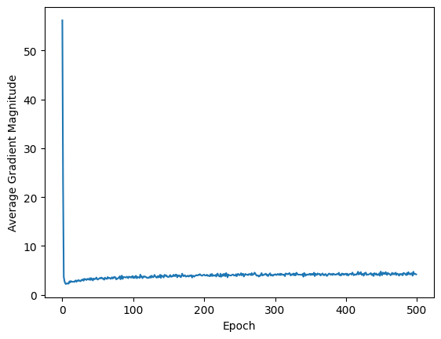

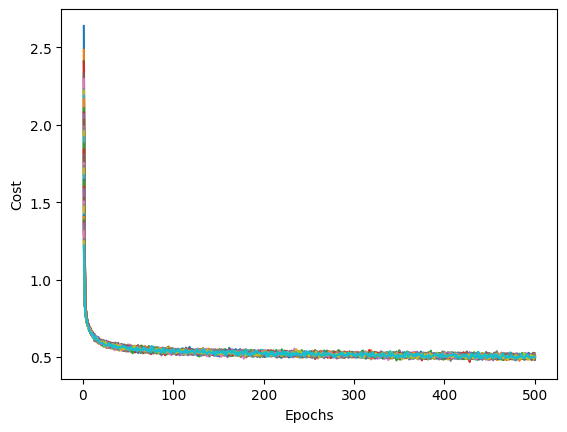

```
Accuracy: 0.7399614961496149
```

```python
params = { 'n_hidden_1':30,'n_hidden_2':30, 'n_hidden_3':30,'n_hidden_4':30,
         'C':0.1, 'epochs':500, 'eta':0.001,
         'alpha':0.001, 'decrease_const':1e-5, 'minibatches':50,
         'shuffle':True,'random_state':1}
# model = TLPVectorizedMiniBatchCrossEntropyGlorot(n_hidden=30, C=0.0, epochs=50, eta=0.001, random_state=42)
model = FiveLayerPerceptronRMSProp(**params)
model.fit(X_train, y_train, print_progress=True)
model.plot_grad_avg()

# plot the loss over time to ensure convergence
plt.plot(range(1, len(model.cost_)+1), model.cost_)
plt.xlabel("Epochs")
plt.ylabel("Cost")
plt.show()

# evaluate the model on the test set
y_pred = model.predict(X_test)

# convert y_pred into a one-hot encoded dataframe
y_pred = convert_data(y_pred)

# Get accuracy
accuracy = accuracy_score(y_test, y_pred)
print("Accuracy:", accuracy)
```

The accuracy of the 5-layer model increased from 73.274% to 73.996% after using RMSProp as the adaptive learning method for this model. RMSProp enhanced the performance of the model by dynamically adjusting the learning rate, which helped to stabilize training. Using RMSProp also addressed issues such as vanishing gradients, allowing the 5-layer model to learn more effectively. If we added further epochs, the model would likely improve in accuracy because RMSProp would continue adapting the learning rate, optimizing the model's convergence over time.

## Part 4-Exceptional Work - ADAM

```python
class FiveLayerPerceptronAdam(FiveLayerPerceptronRMSProp):
    def __init__(self, beta1=0.9, beta2=0.999, eps=1e-8, **kwargs):
        super().__init__(**kwargs)
        self.beta1 = beta1
        self.beta2 = beta2
        self.eps = eps
        self.m1 = self.m2 = self.m3 = self.m4 = self.m5 = 0
        self.v1 = self.v2 = self.v3 = self.v4 = self.v5 = 0
        self.t = 0

    def _update_weights(self, grad1, grad2, grad3, grad4, grad5):
        self.t += 1
        self.m1 = self.beta1 * self.m1 + (1 - self.beta1) * grad1
        self.m2 = self.beta1 * self.m2 + (1 - self.beta1) * grad2
        self.m3 = self.beta1 * self.m3 + (1 - self.beta1) * grad3
        self.m4 = self.beta1 * self.m4 + (1 - self.beta1) * grad4
        self.m5 = self.beta1 * self.m5 + (1 - self.beta1) * grad5

        self.v1 = self.beta2 * self.v1 + (1 - self.beta2) * grad1**2
        self.v2 = self.beta2 * self.v2 + (1 - self.beta2) * grad2**2
        self.v3 = self.beta2 * self.v3 + (1 - self.beta2) * grad3**2
        self.v4 = self.beta2 * self.v4 + (1 - self.beta2) * grad4**2
        self.v5 = self.beta2 * self.v5 + (1 - self.beta2) * grad5**2

        m1_corr = self.m1 / (1 - self.beta1**self.t)
        m2_corr = self.m2 / (1 - self.beta1**self.t)
        m3_corr = self.m3 / (1 - self.beta1**self.t)
        m4_corr = self.m4 / (1 - self.beta1**self.t)
        m5_corr = self.m5 / (1 - self.beta1**self.t)

        v1_corr = self.v1 / (1 - self.beta2**self.t)
        v2_corr = self.v2 / (1 - self.beta2**self.t)
        v3_corr = self.v3 / (1 - self.beta2**self.t)
        v4_corr = self.v4 / (1 - self.beta2**self.t)
        v5_corr = self.v5 / (1 - self.beta2**self.t)

        self.W1 -= self.eta / (np.sqrt(v1_corr) + self.eps) * m1_corr
        self.W2 -= self.eta / (np.sqrt(v2_corr) + self.eps) * m2_corr
        self.W3 -= self.eta / (np.sqrt(v3_corr) + self.eps) * m3_corr
        self.W4 -= self.eta / (np.sqrt(v4_corr) + self.eps) * m4_corr
        self.W5 -= self.eta / (np.sqrt(v5_corr) + self.eps) * m5_corr
```

```
Epoch: 500/500
```

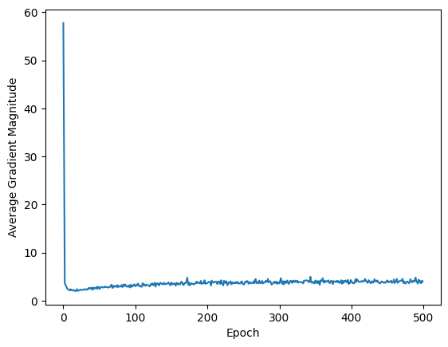

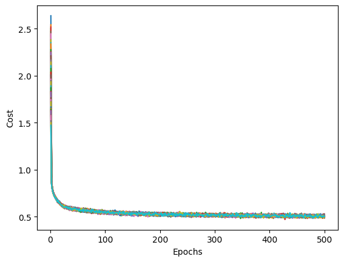

```
Accuracy: 0.7427805280528053
```

```python
params = { 'n_hidden_1':30,'n_hidden_2':30, 'n_hidden_3':30,'n_hidden_4':30,
         'C':0.1, 'epochs':500, 'eta':0.001,
         'alpha':0.001, 'decrease_const':1e-5, 'minibatches':50,
         'shuffle':True,'random_state':1}
# model = TLPVectorizedMiniBatchCrossEntropyGlorot(n_hidden=30, C=0.0, epochs=50, eta=0.001, random_state=42)
model = FiveLayerPerceptronAdam(**params)
model.fit(X_train, y_train, print_progress=True)
model.plot_grad_avg()
# plot the loss over time to ensure convergence
plt.plot(range(1, len(model.cost_)+1), model.cost_)
plt.xlabel("Epochs")
plt.ylabel("Cost")
plt.show()

# evaluate the model on the test set
y_pred = model.predict(X_test)

# convert y_pred into a one-hot encoded dataframe
y_pred = convert_data(y_pred)

# Get accuracy
accuracy = accuracy_score(y_test, y_pred)
print("Accuracy:", accuracy)
```

## Reference

“US Census Demographic Data.” Kaggle, 3 Mar. 2019, https://www.kaggle.com/muonneutrino/us-census-demographic-data/data.

"RMSProp Optimizer in Deep Learning." GeeksForGeeks, 24 July 2024, https://www.geeksforgeeks.org/rmsprop-optimizer-in-deep-learning/.